# Minimum Wage and Inflation, Discourse

Chris G Martin

May 16, 2017

# Overview

This final project was designed to visualize and analyze the current U.S. policy topic on minimum wage and possible correlations with inflation and employement. After having started working on this project, I came acorss a fairly recent publication from the National Employment Law Project titled: [‘Raise Wages, Kill Jobs? Seven Decades of Historical Data Find No Correlation Between Minimum Wage Increases and Employement Levels’](http://www.nelp.org/publication/raise-wages-kill-jobs-no-correlation-minimum-wage-increases-employment-levels/). This is an interesting brief with many parallels to what I’m looking at showing in this project, however my focus is on the interactive visualization aspect and not the correlation itself. My motivations for the project include a passing interest in the topic and I have no alterior motives here (such as a lucrative employment contract or salary). But please, feel free to send some money my way!

**Note: This is Part One of Three**

This part includes data gathering for the raw data, explainations as to the how and why a specific data set was used vs alternative sets, analysis of the data, and discussion. Part Two is a Jupyter notebook running a Python script to extract data

Part Three includes an interactive d3 visualization of the data.

## Consumer Price Index (CPI)

Quoted from the United States’ Department of Labor’s (DOL) Bureau of Labor Statistics (BLS):

“The Consumer Price Index (CPI) is a statistical measure of change, over time, of the prices of goods and services in major expenditure groups–such as food, housing, apparel, transportation, and medical care–typically purchased by urban consumers. Essentially, it compares the cost of a sample”market basket" of goods and services in a specific month relative to the cost of the same “market basket” in an earlier reference period. This reference period is designated as the base period."

Not surprisingly, the BLS maintains several varieties of the CPI as it has developed over the years. To better analyse the price change through the CPI over time, there are three main different applicable data repositories: 1) Average Price Data [(AP)](https://download.bls.gov/pub/time.series/ap/ap.txt), 2) CPI for Urban Consumers as introduced in 1987 [(MU)](https://download.bls.gov/pub/time.series/mu/Mu.txt), and 3) the revised CPI for Urban Consumers as introduced in 1998 [(CU)](https://download.bls.gov/pub/time.series/cu/cu.txt). The AP data is most useful to compare prices for items across different regions / urban areas and worth noting that this data is “best used to measure the price level in a particular month, not to measure price change over time” (BLS’ AP.txt). The difference between the MU dataset and CU dataset is that the CU dataset is the most recent methodology for calculating the CPI, and likely the best option for this project without getting into specifics on how or why. As such, the [full CU dataset](https://download.bls.gov/pub/time.series/cu/) will be used for this project.

## Minimum Wage Rates

Minimum wage is much more difficult to analyze, but the general minimum wage rate will be used (as opposed to tip-based workers). The website for the [U.S. Department of Labor](https://www.dol.gov/whd/state/stateMinWageHis.htm) is handy for this as it includes the changes to the basic minimum wages in non-farm employment under state law, for years between 1968-2016. There are many caveats to the data as I display it in this project, so be sure to read the notes throughout this report to understand what has changed.

## US Employment Levels

Another data field I could include is the unemployment rate, and possibly minimum wage as a function of unemployment. Due to time constraints, I’ve decided to skip this section, but see the notes at the end for *next steps* for items that could be included in the analysis and project for future value-add! The data from the [Bureau of Labor Statistics](https://www.bls.gov/lau/metrossa.htm) is primarily useful.

# Data Gathering and Data Formatting

## CPI CU Data

Thankfully, the CPI data has been maintained and is still openly available on the [BLS website](https://www.bls.gov/). Using the properly formatted dataset which includes “All Items”, we can take a look at what this actually means and looks like:

```r
CPI <- read.csv2('https://raw.githubusercontent.com/chrisgmartin/DATA608/master/Final/cu.data.1.AllItems', header=TRUE, sep='\t')
head(CPI)
```

```
##           series_id year period        value footnote_codes
## 1 CUSR0000SA0       1947    M01        21.48             NA
## 2 CUSR0000SA0       1947    M02        21.62             NA
## 3 CUSR0000SA0       1947    M03        22.00             NA
## 4 CUSR0000SA0       1947    M04        22.00             NA
## 5 CUSR0000SA0       1947    M05        21.95             NA
## 6 CUSR0000SA0       1947    M06        22.08             NA
```

Looks great, doesn’t it? Well, I’m just as confused as you are. With this data, it is probably helpful to include translations for the various ID’s and codes. Also, one item that it interesting to note is that our “All Items” CPI dataset only includes the aggregation of all items in both the old and revised CPI base measurement. This is for the sake of simplicity of the analysis, with full details available but not used. We just want the general idea of inflation, not the specific items.

### Series Details

The main column of the dataset is the “Series ID” number. The BLS includes a key for this called “Series Details” which includes data for series_id and a ton of metadata that will be incredibly helpful to understand what we’re looking at. Let’s take a look at it and add it to our “full” CPI data.

Unfortunately, the series details set is not perfectly formatted but all it took was a simple save to the desktop and some light spacing, then it was ready to import. The header available in the CPI includes:

```r
CPIseries <- read.csv2('https://raw.githubusercontent.com/chrisgmartin/DATA608/master/Final/cu.series', header=TRUE, sep='\t')
head(CPIseries)
```

```
##           series_id area_code item_code seasonal periodicity_code
## 1 CUSR0000SA0            0000       SA0        S                R
## 2 CUSR0000SA0E           0000      SA0E        S                R
## 3 CUSR0000SA0L1          0000     SA0L1        S                R
## 4 CUSR0000SA0L12         0000    SA0L12        S                R
## 5 CUSR0000SA0L12E        0000   SA0L12E        S                R
## 6 CUSR0000SA0L12E4       0000  SA0L12E4        S                R
##   base_code base_period
## 1         S 1982-84=100
## 2         S 1982-84=100
## 3         S 1982-84=100
## 4         S 1982-84=100
## 5         S 1982-84=100
## 6         S 1982-84=100
##                                                                                                                    series_title
## 1                                                      All items in U.S. city average, all urban consumers, seasonally adjusted
## 2                                                         Energy in U.S. city average, all urban consumers, seasonally adjusted
## 3                                            All items less food in U.S. city average, all urban consumers, seasonally adjusted
## 4                                All items less food and shelter in U.S. city average, all urban consumers, seasonally adjusted
## 5                       All items less food, shelter, and energy in U.S. city average, all urban consumers, seasonally adjusted
## 6 All items less food, shelter, energy, and used cars and trucks in U.S. city average, all urban consumers, seasonally adjusted
##   footnote_codes begin_year begin_period end_year end_period
## 1             NA       1947          M01     2017        M03
## 2             NA       1957          M01     2017        M03
## 3             NA       1947          M01     2017        M03
## 4             NA       1967          M01     2017        M03
## 5             NA       1967          M01     2017        M03
## 6             NA       1967          M01     2017        M03
```

Now to merge it with the original:

```r
CPI <- join(CPI, CPIseries, by='series_id')
head(CPI)
```

```
##           series_id year period        value footnote_codes area_code
## 1 CUSR0000SA0       1947    M01        21.48             NA      0000
## 2 CUSR0000SA0       1947    M02        21.62             NA      0000
## 3 CUSR0000SA0       1947    M03        22.00             NA      0000
## 4 CUSR0000SA0       1947    M04        22.00             NA      0000
## 5 CUSR0000SA0       1947    M05        21.95             NA      0000
## 6 CUSR0000SA0       1947    M06        22.08             NA      0000
##   item_code seasonal periodicity_code base_code base_period
## 1       SA0        S                R         S 1982-84=100
## 2       SA0        S                R         S 1982-84=100
## 3       SA0        S                R         S 1982-84=100
## 4       SA0        S                R         S 1982-84=100
## 5       SA0        S                R         S 1982-84=100
## 6       SA0        S                R         S 1982-84=100
##                                                               series_title
## 1 All items in U.S. city average, all urban consumers, seasonally adjusted
## 2 All items in U.S. city average, all urban consumers, seasonally adjusted
## 3 All items in U.S. city average, all urban consumers, seasonally adjusted
## 4 All items in U.S. city average, all urban consumers, seasonally adjusted
## 5 All items in U.S. city average, all urban consumers, seasonally adjusted
## 6 All items in U.S. city average, all urban consumers, seasonally adjusted
##   footnote_codes begin_year begin_period end_year end_period
## 1             NA       1947          M01     2017        M03
## 2             NA       1947          M01     2017        M03
## 3             NA       1947          M01     2017        M03
## 4             NA       1947          M01     2017        M03
## 5             NA       1947          M01     2017        M03
## 6             NA       1947          M01     2017        M03
```

### Item Codes

Still, more codes and more questions. What exactly are these items being refered to in the column for ‘item_code’?

```r
CPIitem <- read.csv2('https://raw.githubusercontent.com/chrisgmartin/DATA608/master/Final/cu.item', header=TRUE, sep='\t')
CPIitem <- cbind('item_code2' = rownames(CPIitem), CPIitem)
rownames(CPIitem) <- 1:nrow(CPIitem)
colnames(CPIitem) <- c('item_code', 'item_name', 'display_level', 'selectable', 'sort_sequence', 'NA')
head(CPIitem)
```

```
##   item_code                                          item_name
## 1       AA0                               All items - old base
## 2      AA0R Purchasing power of the consumer dollar - old base
## 3       SA0                                          All items
## 4      SA0E                                             Energy
## 5     SA0L1                                All items less food
## 6    SA0L12                    All items less food and shelter
##   display_level selectable sort_sequence NA
## 1             0       TRUE             2 NA
## 2             0       TRUE           399 NA
## 3             0       TRUE             1 NA
## 4             1       TRUE           374 NA
## 5             1       TRUE           358 NA
## 6             1       TRUE           361 NA
```

As mentioned before, the items included in this set are the aggregated “All Items” codes in both old and revised CPI base measurements. Merge with the original:

```r
CPI <- join(CPI, CPIitem, by='item_code')
```

### Area Codes

The area codes will give us geographic urban areas:

```r
CPIarea <- read.csv2('https://raw.githubusercontent.com/chrisgmartin/DATA608/master/Final/cu.area', header=TRUE, sep='\t')
CPIarea <- cbind('area_code2' = rownames(CPIarea), CPIarea)
rownames(CPIarea) <- 1:nrow(CPIarea)
colnames(CPIarea) <- c('area_code', 'area_name', 'display_level', 'selectable', 'sort_sequence', 'NA')
head(CPIarea)
```

```
##   area_code                          area_name display_level selectable
## 1      0000                  U.S. city average             0       TRUE
## 2      0100                    Northeast urban             0       TRUE
## 3      0200                      Midwest urban             0       TRUE
## 4      0300                        South urban             0       TRUE
## 5      0400                         West urban             0       TRUE
## 6      A000 Size Class A (more than 1,500,000)             0       TRUE
##   sort_sequence NA
## 1             1 NA
## 2             5 NA
## 3            12 NA
## 4            24 NA
## 5            34 NA
## 6             2 NA
```

Merge with the original:

```r
CPI <- join(CPI, CPIarea, by='area_code')
```

### Base Codes

Base codes are the measurement for CPI:

```r
CPIbase <- read.csv2('https://raw.githubusercontent.com/chrisgmartin/DATA608/master/Final/cu.base', header=TRUE, sep='\t')
CPIbase <- cbind('base_code2' = rownames(CPIbase), CPIbase)
rownames(CPIbase) <- 1:nrow(CPIbase)
colnames(CPIbase) <- c('base_code', 'base_name', 'NA')
CPIbase
```

```
##   base_code base_name NA
## 1         A Alternate NA
## 2         S   Current NA
```

Merge with the original:

```r
CPI <- join(CPI, CPIbase, by='base_code')
```

### Period Codes

Period codes transalte the periods from the M or S codes to their English month / period names or abbreviations:

```r
CPIperiod <- read.csv2('https://raw.githubusercontent.com/chrisgmartin/DATA608/master/Final/cu.period', header=TRUE, sep='\t')
head(CPIperiod)
```

```
##   period period_abbr period_name
## 1    M01         JAN     January
## 2    M02         FEB    February
## 3    M03         MAR       March
## 4    M04         APR       April
## 5    M05         MAY         May
## 6    M06         JUN        June
```

Merge with the original:

```r
CPI <- join(CPI, CPIperiod, by='period')
```

### Periodicity Codes

Periodicity refers to the periodic nature of the measurement:

```r
CPIperiodicity <- read.csv2('https://raw.githubusercontent.com/chrisgmartin/DATA608/master/Final/cu.periodicity', header=TRUE, sep='\t')
CPIperiodicity <- cbind('periodicity_code2' = rownames(CPIperiodicity), CPIperiodicity)
rownames(CPIperiodicity) <- 1:nrow(CPIperiodicity)
colnames(CPIperiodicity) <- c('periodicity_code', 'periodcity_name', 'NA')
CPIperiodicity
```

```
##   periodicity_code periodcity_name NA
## 1                R         Monthly NA
## 2                S     Semi-Annual NA
```

Merge with the original:

```r
CPI <- join(CPI, CPIperiodicity, by='periodicity_code')
```

### CPI Summary

Finally, our CPI dataset is full and complete. It’s extremely large, but it’s very full of information. Here’s an R Summary (with NA columns removed)!

```r
cols <- c(1:4, 6:12, 14:18, 21, 23:26, 28, 30:32)
CPI <- CPI[, cols]
summary(CPI)
```

```
##              series_id          year          period
##  CUUR0000AA0      : 1355   Min.   :1913   M13    : 4884
##  CUUR0000SA0      : 1355   1st Qu.:1964   M12    : 3951
##  CUURA101AA0      : 1087   Median :1988   M06    : 3744
##  CUURA101SA0      : 1087   Mean   :1982   M03    : 3103
##  CUURA207AA0      : 1087   3rd Qu.:2003   M09    : 3082
##  CUURA207SA0      : 1087   Max.   :2017   M10    : 3068
##  (Other)          :42457                  (Other):27683
##           value         area_code       item_code     seasonal
##          17.3:  110   0000   : 3751   SA0    :26122   S:  843
##          17.4:  103   A101   : 2372   AA0    :23393   U:48672
##          17.1:   82   A207   : 2372   AA0R   :    0
##          17.5:   79   A421   : 2372   SA0E   :    0
##          29.8:   76   A102   : 2140   SA0L1  :    0
##          14.0:   72   A208   : 2008   SA0L12 :    0
##  (Other)     :48993   (Other):34500   (Other):    0
##  periodicity_code base_code            base_period
##  R:41678          A:23393   1982-84=100      :23701
##  S: 7837          S:26122   1967=100         :15914
##                             DECEMBER 1977=100: 6336
##                             DECEMBER 1996=100: 1620
##                             DECEMBER 1986=100:  964
##                             NOVEMBER 1977=100:  375
##                             (Other)          :  605
##                                                                                                                       series_title
##  All items - old base in U.S. city average, all urban consumers, not seasonally adjusted                                    : 1454
##  All items in U.S. city average, all urban consumers, not seasonally adjusted                                               : 1454
##  All items - old base in Chicago-Gary-Kenosha, IL-IN-WI, all urban consumers, not seasonally adjusted                       : 1186
##  All items - old base in Los Angeles-Riverside-Orange County, CA, all urban consumers, not seasonally adjusted              : 1186
##  All items - old base in New York-Northern New Jersey-Long Island, NY-NJ-CT-PA, all urban consumers, not seasonally adjusted: 1186
##  All items in Chicago-Gary-Kenosha, IL-IN-WI, all urban consumers, not seasonally adjusted                                  : 1186
##  (Other)                                                                                                                    :41863
##    begin_year    begin_period      end_year      end_period
##  Min.   :1913   M12    :35390   Min.   :1986   M03    :26031
##  1st Qu.:1914   S01    : 7768   1st Qu.:2016   M02    : 8964
##  Median :1917   M01    : 3821   Median :2017   S03    : 7837
##  Mean   :1945   M11    : 1387   Mean   :2013   M13    : 5753
##  3rd Qu.:1977   M03    :  560   3rd Qu.:2017   M11    :  930
##  Max.   :2002   M05    :  264   Max.   :2017   M01    :    0
##                 (Other):  325                  (Other):    0
```

[output cut: 17 more lines]

```
##  Min.   :0.0000   Mode:logical   Min.   : 1.00   Alternate:23393
##  1st Qu.:1.0000   TRUE:49515     1st Qu.: 8.00   Current  :26122
##  Median :1.0000   NA's:0         Median :17.00
##  Mean   :0.7771                  Mean   :19.78
##  3rd Qu.:1.0000                  3rd Qu.:31.00
##  Max.   :1.0000                  Max.   :45.00
##
##   period_abbr            period_name       periodcity_name
##  AN AV  : 7502   Annual Average: 7502   Monthly    :41678
##  DEC    : 3951   December      : 3951   Semi-Annual: 7837
##  JUN    : 3744   June          : 3744
##  MAR    : 3103   March         : 3103
##  SEP    : 3082   September     : 3082
##  OCT    : 3068   October       : 3068
##  (Other):25065   (Other)       :25065
```

I like to keep my environment as clean as I can, so here’s a quick section to clean out the tables we no longer need:

```r
rm(CPIarea)
rm(CPIbase)
rm(CPIitem)
rm(CPIperiod)
rm(CPIperiodicity)
rm(CPIseries)
```

### Export CPI Table

For use in other applications, it’s nice to have a local copy of the data. Here is the code to export the CSV.

```r
write.csv(CPI, file="CPI.csv")
```

## Minimum Wage Data

**Per Part Two of Three**: The data table was only supplied in a webtable and had to be scraped by a Python script. For more details of the [Python script, click here](https://github.com/chrisgmartin/DATA608/blob/master/Final/martin_chris_final_parttwo.ipynb). The data was then exported from Python as a CSV where it can be imported into R. Here is that import:

```r
MWR <- read.csv2('https://raw.githubusercontent.com/chrisgmartin/DATA608/master/Final/dolwages.csv', header=FALSE, sep='\t', stringsAsFactors = FALSE)
head(MWR)
```

```
##                           V1
## 1    <td>Federal (FLSA)</td>
## 2 <td>$1.15 &amp; $1.60</td>
## 3 <td>$1.30 &amp; $1.60</td>
## 4            <td>$1.60 </td>
## 5 <td>$2.20 &amp; $2.30</td>
## 6            <td>$2.90 </td>
```

As mentioned in the script, this data is messy. It needs to be cleaned. That’s what we’ll do in this section.

### The Eight Deadly Rows

One aspect of this table is that every 8 rows relate to the data corresponding to its state in the first row, until the last set of data points in which every 4 rows relate to data corresponding to the state in the first row. First, we’ll breakout the table for every 8 row patterns:

```r
#need to iterate over each 8 records
#create a list of multiples from 1-220
list8 <- (2:220-1)
list8 <- c(1,list8*8+1)

temp <- unlist(MWR)
#iterate over each record in the multiples
clean_doltable8 <- function(table, iterable){
  df <- data.frame()
  for (i in 1:length(iterable)){
    a <- iterable[i]
    b <- a+1
    c <- a+2
    d <- a+3
    e <- a+4
    f <- a+5
    g <- a+6
    h <- a+7
    #find the value for each variable
    #append each with new variable
    df[i,1] <- table[a]
    df[i,2] <- table[b]
    df[i,3] <- table[c]
    df[i,4] <- table[d]
    df[i,5] <- table[e]
    df[i,6] <- table[f]
    df[i,7] <- table[g]
    df[i,8] <- table[h]
  }
  colnames(df) <- c('state', '1968', '1970', '1972', '1976', '1979', '1980', '1981')
  df
}

temp2 <- clean_doltable8(temp, list8)
head(temp2)
```

```
##                     state                                     1968
## 1 <td>Federal (FLSA)</td>               <td>$1.15 &amp; $1.60</td>
## 2        <td>Alabama</td>                             <td>...</td>
## 3         <td>Alaska</td>                            <td>2.10</td>
## 4        <td>Arizona</td> <td>18.72 \n\n\n      - 26.40/wk(b)</td>
## 5       <td>Arkansas</td>                     <td>1.25/day(b)</td>
## 6     <td>California</td>                         <td>1.65(b)</td>
##                                       1970                       1972
## 1               <td>$1.30 &amp; $1.60</td>            <td>$1.60 </td>
## 2                             <td>...</td>               <td>...</td>
## 3                            <td>2.10</td>              <td>2.10</td>
## 4 <td>18.72 \n\n\n      - 26.40/wk(b)</td> <td>18.72-26.40/wk(b)</td>
## 5                            <td>1.10</td>              <td>1.20</td>
## 6                         <td>1.65(b)</td>           <td>1.65(b)</td>
##                         1976            1979            1980
## 1 <td>$2.20 &amp; $2.30</td> <td>$2.90 </td> <td>$3.10 </td>
## 2               <td>...</td>    <td>...</td>    <td>...</td>
## 3              <td>2.80</td>   <td>3.40</td>   <td>3.60</td>
## 4             <td>Â ...</td>    <td>...</td>    <td>...</td>
## 5              <td>1.90</td>   <td>2.30</td>   <td>2.55</td>
## 6              <td>2.00</td>   <td>2.90</td>   <td>2.90</td>
##              1981
## 1 <td>$3.35 </td>
## 2    <td>...</td>
## 3   <td>3.85</td>
## 4    <td>...</td>
## 5   <td>2.70</td>
## 6   <td>3.35</td>
```

It looks good, but now every state is stacked on top of each other (i.e. row 56 is Federal again). Fixing that is easy:

```r
temp3 <- temp2[1:55,1:8]
temp4 <- temp2[56:110,2:8]
temp5 <- temp2[111:165,2:8]
temp6 <- temp2[166:nrow(temp2),2:8]
temp7 <- cbind(temp3, temp4)
temp7 <- cbind(temp7, temp5)
temp7 <- cbind(temp7, temp6)
colnames(temp7) <- c('state', '1968', '1970', '1972', '1976', '1979', '1980', '1981', '1988', '1991', '1992', '1994', '1996', '1997', '1998', '2000', '2001', '2002', '2003', '2004', '2005', '2006', '2007', '2008', '2009', '2010', '2011', '2012', '2013')
head(temp7)
```

```
##                     state                                     1968
## 1 <td>Federal (FLSA)</td>               <td>$1.15 &amp; $1.60</td>
## 2        <td>Alabama</td>                             <td>...</td>
## 3         <td>Alaska</td>                            <td>2.10</td>
## 4        <td>Arizona</td> <td>18.72 \n\n\n      - 26.40/wk(b)</td>
## 5       <td>Arkansas</td>                     <td>1.25/day(b)</td>
## 6     <td>California</td>                         <td>1.65(b)</td>
##                                       1970                       1972
## 1               <td>$1.30 &amp; $1.60</td>            <td>$1.60 </td>
## 2                             <td>...</td>               <td>...</td>
## 3                            <td>2.10</td>              <td>2.10</td>
## 4 <td>18.72 \n\n\n      - 26.40/wk(b)</td> <td>18.72-26.40/wk(b)</td>
## 5                            <td>1.10</td>              <td>1.20</td>
## 6                         <td>1.65(b)</td>           <td>1.65(b)</td>
##                         1976            1979            1980
```

[output cut: 111 more lines]

Now repeate those steps for the 4 row patterns and merge to get the full set all in one table:

```r
#need to iterate over each 4 records
#create a list of multiples for the 55 states
list4 <- (2:55-1)
list4 <- c(1,list4*4+1)

temp8 <- temp[1761:1980]
#iterate over each record in the multiples
clean_doltable4 <- function(table, iterable){
  df <- data.frame()
  for (i in 1:length(iterable)){
    a <- iterable[i]
    b <- a+1
    c <- a+2
    d <- a+3
    #find the value for each variable
    #append each with new variable
    df[i,1] <- table[b]
    df[i,2] <- table[c]
    df[i,3] <- table[d]
  }
  colnames(df) <- c('2014', '2015', '2016')
  df
}

temp9 <- clean_doltable4(temp8, list4)
#merge with main table
temp10 <- cbind(temp7,temp9)
head(temp10)
```

```
##                     state                                     1968
## 1 <td>Federal (FLSA)</td>               <td>$1.15 &amp; $1.60</td>
## 2        <td>Alabama</td>                             <td>...</td>
## 3         <td>Alaska</td>                            <td>2.10</td>
## 4        <td>Arizona</td> <td>18.72 \n\n\n      - 26.40/wk(b)</td>
## 5       <td>Arkansas</td>                     <td>1.25/day(b)</td>
## 6     <td>California</td>                         <td>1.65(b)</td>
##                                       1970                       1972
## 1               <td>$1.30 &amp; $1.60</td>            <td>$1.60 </td>
## 2                             <td>...</td>               <td>...</td>
## 3                            <td>2.10</td>              <td>2.10</td>
## 4 <td>18.72 \n\n\n      - 26.40/wk(b)</td> <td>18.72-26.40/wk(b)</td>
## 5                            <td>1.10</td>              <td>1.20</td>
## 6                         <td>1.65(b)</td>           <td>1.65(b)</td>
##                         1976            1979            1980
```

[output cut: 125 more lines]

### The Mysterious Symbols

```r
#remove html tags
test <- data.frame(lapply(temp10, function(i){
  str_replace_all(i, "<[^>]+>", '')
}))
#remove html tags and create a new frame for state names
test1 <- data.frame(lapply(temp10, function(i){
  str_replace_all(i, "<[^>]+>", '')
}))
#remove slashes
test <- data.frame(lapply(test, function(i){
  str_replace_all(i, "\\[.*\\]", '')
}))
#remove slashes
test <- data.frame(lapply(test, function(i){
  str_replace_all(i, "\\(.*\\)", '')
}))
#remove alpha characters and separate state names out
test <- data.frame(lapply(test, function(i){
  str_replace_all(i, "[:alpha:]", '')
}))
#remove page breaks and line marks
test <- data.frame(lapply(test, function(i){
  str_replace_all(i, "[\r\n]", '')
}))
#remove rouge slash marks
test <- data.frame(lapply(test, function(i){
  str_replace_all(i, "[//]", '')
}))
#remove all characters before the dash
test <- data.frame(lapply(test, function(i){
  str_replace_all(i, ".*-", '')
}))
#remove all characters before the and symbol
test <- data.frame(lapply(test, function(i){
  str_replace_all(i, ".*&", '')
}))
#remove other pesky items
test <- data.frame(lapply(test, function(i){
  str_replace_all(i, "[^[:alnum:]^..*///' ]", '')
}))
#remove alpha characters and separate state names out
test1 <- data.frame(lapply(test1[1], function(i){
  str_replace_all(i, "[\r\n]", '')
}))

#Puerto Rico is still giving problems, these will manually fix it
test[54,26] <- c(7.25)
test[54,27] <- c(7.25)
test[54,28] <- c(7.25)
test[54,29] <- c(7.25)

#Virigin Islands is also a manually fixed pain
test[55,2] <- '...'
test[55,3] <- '...'
test[55,4] <- '...'
test[55,5] <- '...'

#The weekly rates are a manual fix
test[4,2] <- '...'
test[4,3] <- '...'
test[4,4] <- '...'

#the daily rates are also a fix manually
test[5,2] <- '...'

#add back state names
test <- cbind(test1[1], test[2:ncol(test)])

head(test)
```

```
##            state X1968 X1970 X1972 X1976 X1979 X1980 X1981 X1988 X1991
## 1 Federal (FLSA)  1.60  1.60 1.60   2.30 2.90  3.10  3.35   3.35  3.80
## 2        Alabama   ...   ...   ...   ...   ...   ...   ...   ...   ...
## 3         Alaska  2.10  2.10  2.10  2.80  3.40  3.60  3.85  3.85  4.30
## 4        Arizona   ...   ...   ...   ...   ...   ...   ...   ...   ...
## 5       Arkansas   ...  1.10  1.20  1.90  2.30  2.55  2.70  3.25  3.35
## 6     California  1.65  1.65  1.65  2.00  2.90  2.90  3.35  3.35  4.25
##   X1992 X1994 X1996 X1997 X1998     X2000     X2001     X2002     X2003
## 1  4.25  4.25  4.25  4.75  5.15 5.15      5.15      5.15      5.15
## 2   ...   ...   ...   ...   ...       ...       ...       ...       ...
## 3  4.75  4.75  4.75  5.25  5.65      5.65      5.65      5.65      7.15
## 4   ...   ...   ...   ...   ...       ...       ...       ...       ...
## 5  3.65  4.25  4.25  4.25  5.15      5.15      5.15      5.15      5.15
## 6  4.25  4.25  4.25  4.75  5.15      5.75      6.25      6.75      6.75
##       X2004     X2005       X2006 X2007 X2008 X2009 X2010 X2011 X2012
## 1 5.15      5.15             5.15  5.15  5.85  6.55  7.25  7.25  7.25
## 2       ...       ...         ...   ...   ...   ...   ...   ...   ...
## 3      7.15      7.15        7.15  7.15  7.15  7.15  7.75  7.75  7.75
## 4       ...       ...         ...  6.75  6.90  7.25  7.25  7.35  7.65
## 5      5.15      5.15 5.15         6.25  6.25  6.25  6.25  6.25  6.25
## 6      6.75      6.75        6.75  7.50  8.00  8.00  8.00  8.00  8.00
##   X2013 X2014 X2015 X2016
## 1  7.25  7.25  7.25  7.25
## 2   ...   ...   ...   ...
## 3  7.75  7.75  8.75  9.75
## 4  7.80  7.90  8.05  8.05
## 5  6.25  6.25  7.50  8.00
## 6  8.00  9.00  9.00 10.00
```

PHEW, nearly done. Now need to replace the ‘…’ with the federal rates.

```r
#change all factors to characters
test2 <- data.frame(lapply(test, as.character), stringsAsFactors = FALSE)
#replace periods with federal rates
for(i in 2:ncol(test2)){
  a <- test2[1,i]
  test2[i][test2[i]=='...'] <- a
}

#fix missing values and other errors
test2[42,2] <- c(.5)
test2[55,10] <- c(4.65)
test2[55,10] <- c(4.65)
test2[55,11] <- c(4.65)
test2[55,12] <- c(4.65)


#change values to numeric
test2[2:ncol(test2)] <- lapply(test2[2:ncol(test2)], as.numeric)
MWR_table <- test2
head(MWR_table)
```

```
##            state X1968 X1970 X1972 X1976 X1979 X1980 X1981 X1988 X1991
## 1 Federal (FLSA)  1.60  1.60  1.60   2.3   2.9  3.10  3.35  3.35  3.80
## 2        Alabama  1.60  1.60  1.60   2.3   2.9  3.10  3.35  3.35  3.80
## 3         Alaska  2.10  2.10  2.10   2.8   3.4  3.60  3.85  3.85  4.30
## 4        Arizona  1.60  1.60  1.60   2.3   2.9  3.10  3.35  3.35  3.80
## 5       Arkansas  1.60  1.10  1.20   1.9   2.3  2.55  2.70  3.25  3.35
## 6     California  1.65  1.65  1.65   2.0   2.9  2.90  3.35  3.35  4.25
##   X1992 X1994 X1996 X1997 X1998 X2000 X2001 X2002 X2003 X2004 X2005 X2006
## 1  4.25  4.25  4.25  4.75  5.15  5.15  5.15  5.15  5.15  5.15  5.15  5.15
## 2  4.25  4.25  4.25  4.75  5.15  5.15  5.15  5.15  5.15  5.15  5.15  5.15
## 3  4.75  4.75  4.75  5.25  5.65  5.65  5.65  5.65  7.15  7.15  7.15  7.15
## 4  4.25  4.25  4.25  4.75  5.15  5.15  5.15  5.15  5.15  5.15  5.15  5.15
## 5  3.65  4.25  4.25  4.25  5.15  5.15  5.15  5.15  5.15  5.15  5.15  5.15
## 6  4.25  4.25  4.25  4.75  5.15  5.75  6.25  6.75  6.75  6.75  6.75  6.75
##   X2007 X2008 X2009 X2010 X2011 X2012 X2013 X2014 X2015 X2016
## 1  5.15  5.85  6.55  7.25  7.25  7.25  7.25  7.25  7.25  7.25
## 2  5.15  5.85  6.55  7.25  7.25  7.25  7.25  7.25  7.25  7.25
## 3  7.15  7.15  7.15  7.75  7.75  7.75  7.75  7.75  8.75  9.75
## 4  6.75  6.90  7.25  7.25  7.35  7.65  7.80  7.90  8.05  8.05
## 5  6.25  6.25  6.25  6.25  6.25  6.25  6.25  6.25  7.50  8.00
## 6  7.50  8.00  8.00  8.00  8.00  8.00  8.00  9.00  9.00 10.00
```

And, as mentioned before, I like to keep my environment as clean as I can, so here’s a quick section to clean out the tables we no longer need:

```r
rm(temp10)
rm(temp2)
rm(temp3)
rm(temp4)
rm(temp5)
rm(temp6)
rm(temp7)
rm(temp9)
rm(MWR)
rm(test)
rm(test1)
rm(test2)
```

### Tidying The Table

It’s important to tidy the data, but it’s also incredibly useful with data visualization. [This post is a nice explaination](http://garrettgman.github.io/tidying/) of tidy data, it’s usefulness, and how it’s done in R. Here’s some quick code to do just that:

```r
MWR_tidy <- gather(MWR_table, 'year', 'rate', 2:ncol(MWR_table))
MWR_tidy$year <- gsub('X', '', MWR_tidy$year)
MWR_tidy$year <- as.numeric(MWR_tidy$year)
head(MWR_tidy)
```

```
##            state year rate
## 1 Federal (FLSA) 1968 1.60
## 2        Alabama 1968 1.60
## 3         Alaska 1968 2.10
## 4        Arizona 1968 1.60
## 5       Arkansas 1968 1.60
## 6     California 1968 1.65
```

### MWR Summary

Similar to the summary for CPI data, here’s a summary of the MWR data we’ve beautifully gathered and tidied (one for messy and one for tidy):

```r
summary(MWR_table)
```

```
##     state               X1968           X1970          X1972
##  Length:55          Min.   :0.500   Min.   :0.75   Min.   :0.750
##  Class :character   1st Qu.:1.250   1st Qu.:1.25   1st Qu.:1.400
##  Mode  :character   Median :1.400   Median :1.60   Median :1.600
##                     Mean   :1.382   Mean   :1.45   Mean   :1.528
##                     3rd Qu.:1.600   3rd Qu.:1.60   3rd Qu.:1.600
##                     Max.   :2.100   Max.   :2.10   Max.   :2.250
##      X1976           X1979           X1980           X1981
##  Min.   :1.250   Min.   :1.230   Min.   :1.250   Min.   :1.250
##  1st Qu.:1.950   1st Qu.:2.300   1st Qu.:2.300   1st Qu.:2.300
##  Median :2.300   Median :2.500   Median :2.900   Median :3.100
##  Mean   :2.086   Mean   :2.501   Mean   :2.673   Mean   :2.869
##  3rd Qu.:2.300   3rd Qu.:2.900   3rd Qu.:3.100   3rd Qu.:3.350
##  Max.   :2.800   Max.   :3.400   Max.   :3.600   Max.   :3.850
##      X1988           X1991           X1992           X1994
##  Min.   :1.600   Min.   :1.600   Min.   :1.600   Min.   :1.600
##  1st Qu.:3.300   1st Qu.:3.575   1st Qu.:4.050   1st Qu.:4.250
##  Median :3.350   Median :3.800   Median :4.250   Median :4.250
##  Mean   :3.216   Mean   :3.742   Mean   :4.071   Mean   :4.152
##  3rd Qu.:3.350   3rd Qu.:3.850   3rd Qu.:4.250   3rd Qu.:4.250
##  Max.   :4.850   Max.   :4.850   Max.   :5.450   Max.   :5.250
##      X1996           X1997           X1998           X2000
##  Min.   :1.600   Min.   :1.600   Min.   :1.600   Min.   :1.600
##  1st Qu.:4.250   1st Qu.:4.250   1st Qu.:5.150   1st Qu.:5.150
##  Median :4.250   Median :4.750   Median :5.150   Median :5.150
##  Mean   :4.217   Mean   :4.533   Mean   :4.901   Mean   :5.066
##  3rd Qu.:4.260   3rd Qu.:4.750   3rd Qu.:5.150   3rd Qu.:5.150
##  Max.   :5.250   Max.   :5.750   Max.   :6.150   Max.   :6.500
##      X2001           X2002           X2003           X2004
##  Min.   :1.600   Min.   :2.650   Min.   :2.650   Min.   :2.650
##  1st Qu.:5.150   1st Qu.:5.150   1st Qu.:5.150   1st Qu.:5.150
##  Median :5.150   Median :5.150   Median :5.150   Median :5.150
##  Mean   :5.141   Mean   :5.311   Mean   :5.369   Mean   :5.421
##  3rd Qu.:5.150   3rd Qu.:5.150   3rd Qu.:5.150   3rd Qu.:5.150
##  Max.   :6.750   Max.   :6.900   Max.   :7.150   Max.   :7.160
##      X2005           X2006           X2007           X2008
##  Min.   :2.650   Min.   :2.650   Min.   :2.650   Min.   :2.650
##  1st Qu.:5.150   1st Qu.:5.150   1st Qu.:5.150   1st Qu.:5.850
##  Median :5.150   Median :5.150   Median :6.150   Median :6.330
##  Mean   :5.476   Mean   :5.598   Mean   :6.042   Mean   :6.455
##  3rd Qu.:5.575   3rd Qu.:6.275   3rd Qu.:6.850   3rd Qu.:7.150
##  Max.   :7.350   Max.   :7.630   Max.   :7.930   Max.   :8.070
##      X2009           X2010           X2011           X2012
##  Min.   :2.650   Min.   :5.150   Min.   :5.150   Min.   :5.150
##  1st Qu.:6.550   1st Qu.:7.250   1st Qu.:7.250   1st Qu.:7.250
##  Median :6.850   Median :7.250   Median :7.250   Median :7.250
##  Mean   :6.805   Mean   :7.302   Mean   :7.332   Mean   :7.379
##  3rd Qu.:7.250   3rd Qu.:7.350   3rd Qu.:7.400   3rd Qu.:7.645
##  Max.   :8.550   Max.   :8.550   Max.   :8.670   Max.   :9.040
##      X2013           X2014           X2015            X2016
##  Min.   :5.150   Min.   :5.150   Min.   : 5.150   Min.   : 5.15
##  1st Qu.:7.250   1st Qu.:7.250   1st Qu.: 7.250   1st Qu.: 7.25
##  Median :7.250   Median :7.250   Median : 7.650   Median : 8.00
##  Mean   :7.408   Mean   :7.572   Mean   : 7.845   Mean   : 8.04
##  3rd Qu.:7.765   3rd Qu.:8.000   3rd Qu.: 8.250   3rd Qu.: 8.65
##  Max.   :9.190   Max.   :9.500   Max.   :10.500   Max.   :11.50
```

```r
summary(MWR_tidy)
```

```
##     state                year           rate
##  Length:1705        Min.   :1968   Min.   : 0.500
##  Class :character   1st Qu.:1988   1st Qu.: 3.350
##  Mode  :character   Median :2001   Median : 5.150
##                     Mean   :1997   Mean   : 4.932
##                     3rd Qu.:2009   3rd Qu.: 7.100
##                     Max.   :2016   Max.   :11.500
```

And I’ll remove the now unncessary tables from our clean environment:

```r
rm(MWR)
rm(MWR_table)
```

# Data Visualizations

A preliminary to giving the user the beautiful and interactive data visualization, I personally like to explore what we have to see what we can get from each of our sources. Hopefully this helps build an understanding of what we have before shipping it out.

## CPI Exploration

For CPI data, we’re really looking at too much information. Unfortunately I don’t think my original plan will work due to added complexity; I was hoping to view CPI against the minimum wage in each area (e.g. state) where it applied, however, it is much, much simpler to see the U.S. city average CPI. To add the complexity, I will keep data for all items in the U.S. city average for all urban consumers and include both seasonally adjusted and non-sesasonally adjusted values. To reduce that complexity a bit more, instead of a monthly CPI we’ll look at annual CPI as it better aligns to annual minimum wage rates.

```r
#subset data by series_title
CPI_all <- subset(CPI, series_title == 'All items in U.S. city average, all urban consumers, seasonally adjusted' | series_title == 'All items in U.S. city average, all urban consumers, not seasonally adjusted')

#change all factors to characters
CPI_all <- data.frame(lapply(CPI_all, as.character), stringsAsFactors = FALSE)

#change values and years to numeric
CPI_all$value <- as.numeric(CPI_all$value)
CPI_all$year <- as.numeric(CPI_all$year)

#group items and average values
CPI_table <- CPI_all %>%
  group_by(series_id, year, series_title) %>%
  summarise(., value = mean(value))

head(CPI_table)
```

```
## Source: local data frame [6 x 4]
## Groups: series_id, year [6]
##
##           series_id  year
##               <chr> <dbl>
## 1 CUSR0000SA0        1947
## 2 CUSR0000SA0        1948
## 3 CUSR0000SA0        1949
## 4 CUSR0000SA0        1950
## 5 CUSR0000SA0        1951
## 6 CUSR0000SA0        1952
## # ... with 2 more variables: series_title <chr>, value <dbl>
```

Beautiful. Our data is tidy, it’s clean, and we have exactly what we want! There are now three different series_id’s with two titles. The differences are that we have data for seasonally adjusted, not seasonally adjusted at a monthly rating system, and not seasonally adjusted at a semi-annual rating system. These will be handy! But first we’ll change the titles to something more appropriate: Seasonally Adjusted (monthly average), Not Seasonally Adjusted (monthly average), and Not Seasonally Adjusted (semi-annual average).

```r
CPI_table$title <- CPI_table$series_id
#add title row based on values of the series_id
CPI_table$title[CPI_table$series_id == 'CUSR0000SA0      '] <- 'Seasonally Adjusted (monthly average)'
CPI_table$title[CPI_table$series_id == 'CUUR0000SA0      '] <- 'Not Seasonally Adjusted (monthly average)'
CPI_table$title[CPI_table$series_id == 'CUUS0000SA0      '] <- 'Not Seasonally Adjusted (semi-annual average)'

#group to remove extra items
CPI_table <- CPI_table %>%
  group_by(title, year) %>%
  summarise(., value = mean(value))

CPI_table
```

```
## Source: local data frame [209 x 3]
## Groups: title [?]
##
##                                        title  year     value
##                                        <chr> <dbl>     <dbl>
## 1  Not Seasonally Adjusted (monthly average)  1913  9.884615
## 2  Not Seasonally Adjusted (monthly average)  1914 10.015385
## 3  Not Seasonally Adjusted (monthly average)  1915 10.107692
## 4  Not Seasonally Adjusted (monthly average)  1916 10.884615
## 5  Not Seasonally Adjusted (monthly average)  1917 12.823077
## 6  Not Seasonally Adjusted (monthly average)  1918 15.046154
## 7  Not Seasonally Adjusted (monthly average)  1919 17.330769
## 8  Not Seasonally Adjusted (monthly average)  1920 20.038462
## 9  Not Seasonally Adjusted (monthly average)  1921 17.853846
## 10 Not Seasonally Adjusted (monthly average)  1922 16.753846
## # ... with 199 more rows
```

Now let’s take a look at how these values have changed over time:

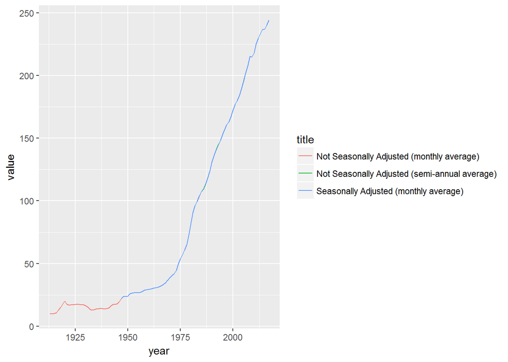

```r
ggplot(CPI_table, aes(x=year, y=value)) + geom_line(aes(color = title))
```

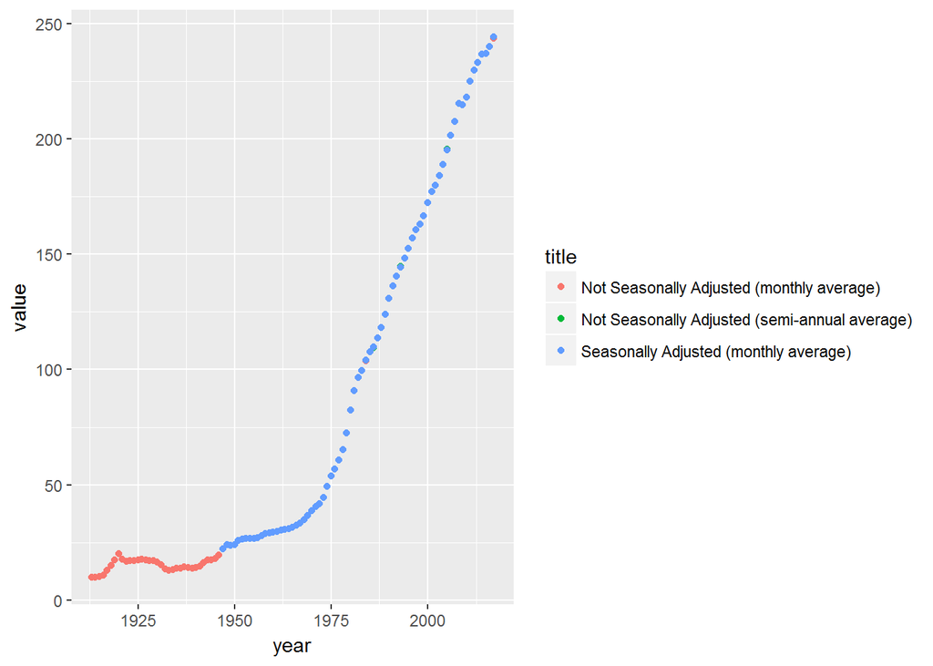

```r
ggplot(CPI_table, aes(x=year, y=value)) + geom_point(aes(color = title))
```

Zooming in a bit helps to see a very, very slight difference between the three methods of CPI calculation:

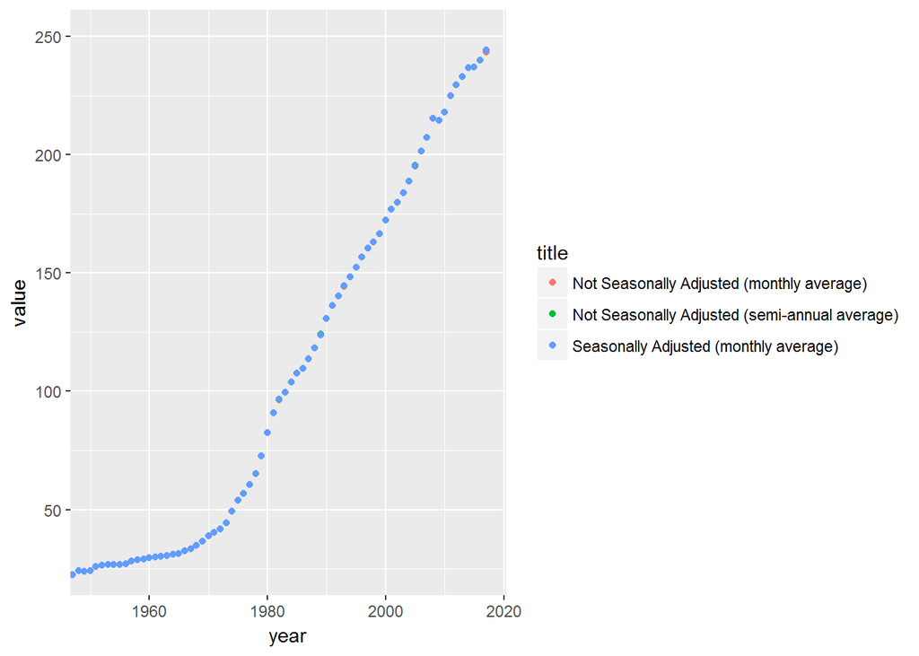

```r
ggplot(CPI_table, aes(x=year, y=value)) + geom_point(aes(color = title)) + coord_cartesian(xlim = c(1950, 2017), ylim = c(25, 250))
```

```r
write.csv(CPI_table, file="CPI_table.csv")
```

And finally, I’ll remove unncessary dataframes from our environment because I like it clean.

```r
rm(CPI)
rm(CPI_all)
```

## MWR Exploration

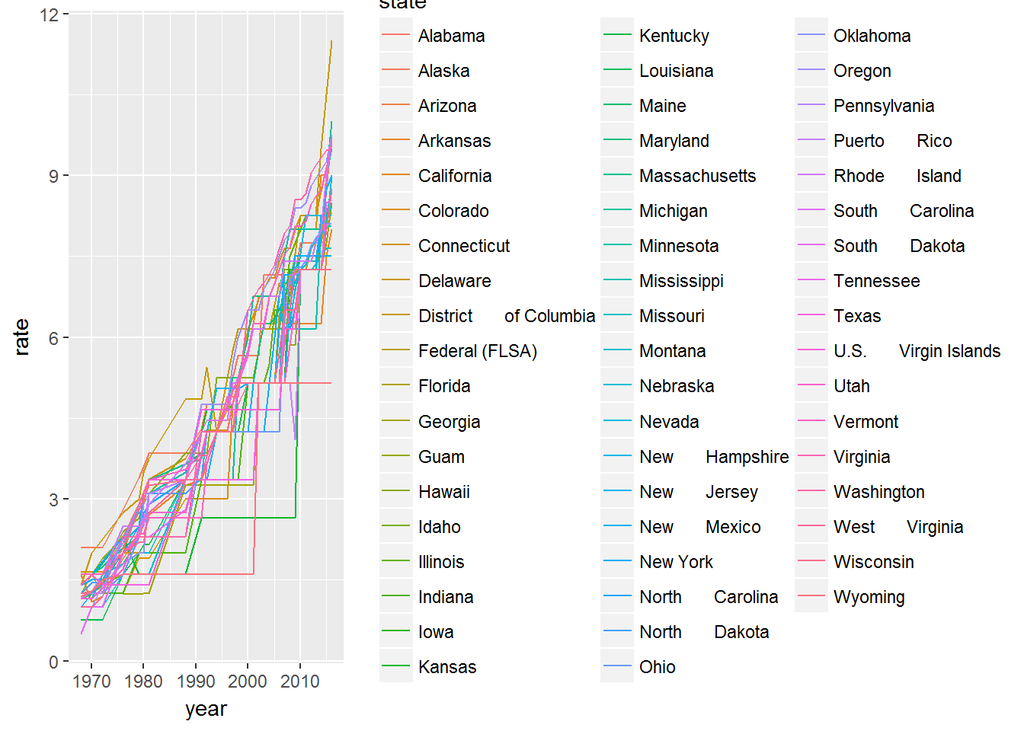

```r
ggplot(MWR_tidy, aes(x=year, y=rate)) + geom_line(aes(color = state))
```

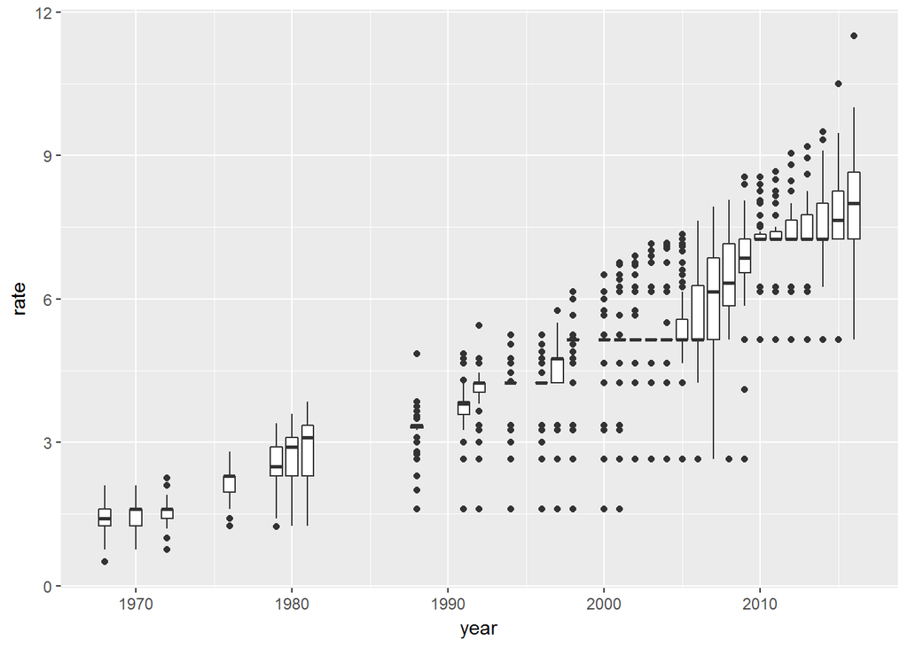

```r
ggplot(MWR_tidy, aes(x=year, y=rate)) + geom_boxplot(aes(group=year), scale='area')
```

Finally, as mentioned I’ll export this final table for use in our third part.

```r
write.csv(MWR_tidy, file="MWR_tidy.csv")
```

# Next Steps

There are certainly areas that could be improved. For example, in the end I decided on taking the annually averaged value for CPI data rather than getting into the weeds and using a monthly scale. I could have also used the regions and match them with their states, rather than a simple U.S. average rate. This would have made a more dynamic end-product.

Performance could also be handidly improved. For one reason, I used a signficant number of *for* loops which are well known to drop performance. There are also a lot of tables being added unnecessarily and a lot of things going on that simply weren’t used. The environment also could have been cleaned eariler that it was but I like to consistency of doing it all together at the end.

Lastly, I could include more data and merge data together for new perspectives. I’m sure there’s a factor of CPI and minimum wage that would have been a great addition to visualizing unemployment statistics.